© Bản quyền thuộc về Quantopian Inc.  
© Bản quyền sửa đổi thuộc về AI Cafe¹  
Giấy phép [Creative Commons Attribution 4.0](https://creativecommons.org/licenses/by/4.0/legalcode).  
[Khuyến cáo](https://aicafe.one/khuyen-cao/)

# Mô hình các nhân tố cơ bản

By Beha Abasi, Maxwell Margenot, and Delaney Mackenzie

Edited by AI Cafe¹

## Mô Hình Các Nhân Tố Cơ Bản Là Gì?

Dữ liệu cơ bản đề cập đến các chỉ số và tỷ lệ đo lường các đặc điểm tài chính của các công ty được lấy từ các báo cáo công khai mà các công ty này đã thực hiện, chẳng hạn như báo cáo thu nhập và bảng cân đối kế toán của họ. Ví dụ về các nhân tố được rút ra từ các tài liệu này bao gồm vốn hóa thị trường, tăng trưởng thu nhập ròng và dòng tiền.

Dữ liệu cơ bản có thể được sử dụng theo nhiều cách, một trong số đó là xây dựng một mô hình nhân tố tuyến tính. Với một tập hợp các nhân tố cơ bản $k$, chúng ta có thể đại diện cho lợi nhuận của một tài sản, $R_t$, như sau:

$$R_t = \alpha_t + \beta_{t, F_1}F_1 + \beta_{t, F_2}F_2 + ... + \beta_{t, F_k}F_k + \epsilon_t$$

Trong đó mỗi $F_j$ đại diện cho một dòng lợi nhuận nhân tố cơ bản. Các dòng lợi nhuận này đến từ các danh mục đầu tư mà giá trị của nó được xác định từ nhân tố tương ứng.

Mô hình nhân tố cơ bản cố gắng xác định các đặc điểm ảnh hưởng đến rủi ro và lợi nhuận của một tài sản. Phần khó khăn nhất trong việc này là xác định nhân tố nào sẽ được sử dụng. Nhiều nghiên cứu đã được thực hiện để xác định các nhân tố quan trọng, và điều làm mọi thứ trở nên khó khăn hơn là việc phát hiện ra một nhân tố quan trọng thường dẫn đến lợi thế của nó bị khai thác! Đây là một trong những lý do tại sao các mô hình nhân tố cơ bản, và các mô hình nhân tố tuyến tính nói chung, lại phổ biến trong tài chính hiện đại. Khi bạn đã tìm thấy các nhân tố quan trọng, bạn cần tính toán mức độ tiếp xúc mà dòng lợi nhuận của tài sản có với từng nhân tố. Điều này tương tự như việc tính toán các khoản bù rủi ro được thảo luận trong bài giảng CAPM.

Khi sử dụng dữ liệu cơ bản, chúng ta gặp phải vấn đề có những nhân tố có thể không dễ dàng so sánh do đơn vị và độ lớn khác nhau của chúng. Để giải quyết điều này, chúng ta áp dụng hai phương pháp khác nhau để đưa dữ liệu lên cùng một thang đo - xây dựng danh mục đầu tư để so sánh các dòng lợi nhuận và chuẩn hóa giá trị của các nhân tố.

## Phương Pháp Một: Xây Dựng Danh Mục Đầu Tư

Phương pháp đầu tiên bao gồm việc sử dụng dữ liệu cơ bản như một hệ thống xếp hạng và tạo ra một danh mục đầu tư cổ phiếu Long-Short dựa trên từng nhân tố. Sau đó, chúng ta sử dụng các dòng lợi nhuận liên quan đến mỗi danh mục làm các nhân tố mô hình của mình.

Một trong những ví dụ nổi tiếng nhất của phương pháp này là mô hình Fama-French. Mô hình Fama-French, và sau đó là mô hình bốn nhân tố Carhart, đã thêm vốn hóa thị trường, tỷ lệ giá trị sổ sách trên giá, và động lực (momentum) vào mô hình CAPM (mô hình mà chỉ bao gồm rủi ro thị trường).

Lịch sử cho thấy, một số nhóm cổ phiếu được coi là có hiệu suất tốt hơn thị trường, cụ thể là những cổ phiếu có vốn hóa thị trường nhỏ, tỷ lệ giá trị sổ sách trên giá cao và những cổ phiếu đã hoạt động tốt trong quá khứ (tức là, chúng có động lực). Thực nghiệm, Fama & French đã phát hiện ra rằng lợi nhuận của những loại cổ phiếu này thường tốt hơn những gì được dự đoán bởi đường thị trường chứng khoán của CAPM.

Để nắm bắt những hiện tượng này, chúng ta sẽ sử dụng các nhân tố đó để tạo ra một hệ thống xếp hạng sẽ được sử dụng trong việc tạo ra các danh mục đầu tư cổ phiếu Long-Short. Các nhân tố sẽ là $SMB$, đo lường lợi nhuận vượt trội của các công ty có vốn hóa thị trường nhỏ so với lớn, $HML$, đo lường lợi nhuận vượt trội của các công ty có tỷ lệ giá trị sổ sách trên giá cao so với thấp, $MOM$, đo lường lợi nhuận vượt trội của những cổ phiếu chiến thắng tháng trước so với những cổ phiếu thua tháng trước, và $EXMRKT$, là một thước đo rủi ro thị trường.

Nói chung, phương pháp này có thể được sử dụng như một mô hình định giá tài sản hoặc để phòng vệ cho các danh mục đầu tư của chúng ta. Cái sau sử dụng hồi quy Fama-Macbeth để tính toán các khoản tiền rủi ro, như đã trình bày trong bài giảng CAPM. Việc phòng vệ có thể đạt được thông qua một hồi quy tuyến tính của lợi nhuận danh mục trên lợi nhuận từ các danh mục đầu tư nhân tố Long-Short. Dưới đây là ví dụ cho cả hai.

### Xây dựng Danh mục Đầu tư như một Mô hình Định giá Tài sản

*Chú ý: dữ liệu cơ bản được lấy từ CSDL của AI Cafe¹, chúng tôi không public dữ liệu này, khi chạy lại notebook các bạn có thể bỏ qua những cell dưới đây*

```python
!curl -fsSLO https://raw.githubusercontent.com/algo-stocks/data/master/data/robusta.py
%run -i robusta.py
```

Chúng ta import các thư viện

```python
import pandas as pd
import numpy as np
import matplotlib.pyplot as plt

from data import universe, get_prices, fin_std, get_fin_stmt, fin_stmt_date_idx, date_reindex
```

Và lấy dữ liệu cần thiết cho bài giảng này:

```python
tickers = np.array(universe('VN100')[:'2023'].iloc[-1].dropna().index)

start_date, end_date = '2024-01-01', '2024-12-31'

# Prices Data
prices = get_prices(*tickers, start_date='2023-12-01', end_date=end_date, field=['close', 'share', 'unadjusted'])
market_caps = 1000 * prices.xs('unadjusted', axis=1, level=1) * prices.xs('share', axis=1, level=1)
closes = prices.xs('close', axis=1, level=1).ffill()
returns = closes.pct_change(fill_method=None)[start_date:]

# Fundamental Data
book_value = fin_std({'_': 302, 'bs26857059': '309+308', 'bs7037699336': 4, 'bs1683709501': '302+303'})
BOOK = pd.DataFrame()
for ticker in tickers:
  bsq = get_fin_stmt(ticker, 'bsq', True)
  bsd = fin_stmt_date_idx(bsq)
  bv = book_value(bsd)
  bv = bv[~bv.index.duplicated(keep='last')]
  BOOK = BOOK.join(bv.to_frame(ticker), how='outer')

book_to_price = date_reindex(BOOK, market_caps.index) / market_caps

# Size
cap_rank = market_caps.rank(axis=1, ascending=False)
R_biggest = returns[cap_rank < 31].mean(axis=1)
R_smallest = returns[cap_rank > 70].mean(axis=1)

# Value
value_rank = book_to_price.rank(axis=1, ascending=False)
R_highpb = returns[value_rank < 31].mean(axis=1)
R_lowpb = returns[value_rank > 70].mean(axis=1)

# Momentum monthly
momentum = (closes - closes.shift(20)) / closes.shift(20)
momentum_rank = momentum.rank(axis=1, ascending=False)
R_top = returns[momentum_rank < 31].mean(axis=1)
R_bottom = returns[momentum_rank > 70].mean(axis=1)

# Risk free and benchmark
R_F = .05/252
M = get_prices('VN100', frequency='index', end_date=end_date).VN100.pct_change()[start_date:]

# Defining our final factors
EXMRKT = M - R_F
SMB = R_smallest - R_biggest # small minus big
HML = R_highpb - R_lowpb # high minus low
MOM = R_top - R_bottom # momentum
```

Bây giờ hãy xem xét từng danh mục Long-Short theo các nhân tố của chúng ta

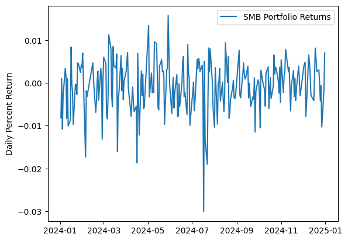

```python
plt.plot(SMB.index, SMB.values)
plt.ylabel('Daily Percent Return')
plt.legend(['SMB Portfolio Returns']);
```

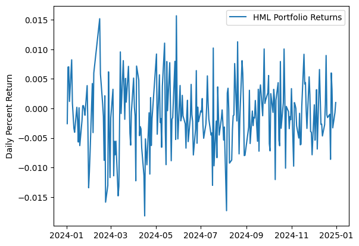

```python
plt.plot(HML.index, HML.values)
plt.ylabel('Daily Percent Return')
plt.legend(['HML Portfolio Returns']);
```

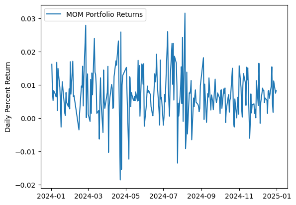

```python
plt.plot(MOM.index, MOM.values)
plt.ylabel('Daily Percent Return')
plt.legend(['MOM Portfolio Returns']);
```

Bây giờ, như chúng ta đã làm trong bài giảng về CAPM, chúng ta sẽ tính toán phần bù rủi ro trên từng nhân tố này bằng cách sử dụng hồi quy Fama-Macbeth.

```python
import itertools
import statsmodels.api as sm
from statsmodels import regression,stats
import scipy
```

```python
# First regression step: estimating the betas
x = sm.add_constant(pd.DataFrame({'EXMRKT': EXMRKT.reindex(returns.index), 'SMB': SMB, 'HML': HML, 'MOM': MOM}))

reg_results = [regression.linear_model.OLS(returns[ticker], x).fit().params for ticker in tickers]

betas = pd.DataFrame(reg_results, index=tickers)
betas = sm.add_constant(betas.drop('const', axis=1))
```

```python
# Second regression step: estimating the risk premia
final_results = regression.linear_model.OLS(returns.mean() - R_F, betas).fit()
final_results.summary()
```

OLS Regression Results

| Dep. Variable: | y | R-squared: | 0.456 |
| --- | --- | --- | --- |
| Model: | OLS | Adj. R-squared: | 0.434 |
| Method: | Least Squares | F-statistic: | 19.95 |
| Date: | Sun, 27 Apr 2025 | Prob (F-statistic): | 6.01e-12 |
| Time: | 09:56:18 | Log-Likelihood: | 590.32 |
| No. Observations: | 100 | AIC: | -1171. |
| Df Residuals: | 95 | BIC: | -1158. |
| Df Model: | 4 |  |  |
| Covariance Type: | nonrobust |  |  |

|  | coef | std err | t | P>\|t\| | [0.025 | 0.975] |
| --- | --- | --- | --- | --- | --- | --- |
| const | 0.0001 | 0.000 | 0.612 | 0.542 | -0.000 | 0.001 |
| EXMRKT | 0.0004 | 0.000 | 1.772 | 0.080 | -4.52e-05 | 0.001 |
| SMB | -0.0005 | 0.000 | -3.732 | 0.000 | -0.001 | -0.000 |
| HML | -0.0009 | 0.000 | -6.585 | 0.000 | -0.001 | -0.001 |
| MOM | 0.0016 | 0.000 | 4.580 | 0.000 | 0.001 | 0.002 |

| Omnibus: | 6.580 | Durbin-Watson: | 2.076 |
| --- | --- | --- | --- |
| Prob(Omnibus): | 0.037 | Jarque-Bera (JB): | 6.340 |
| Skew: | 0.465 | Prob(JB): | 0.0420 |
| Kurtosis: | 3.811 | Cond. No. | 8.75 |

Notes:  
[1] Standard Errors assume that the covariance matrix of the errors is correctly specified.

### Dự Đoán Lợi Nhuận

Như đã thảo luận trong bài giảng CAPM, mô hình hóa yếu tố có thể được sử dụng để dự đoán lợi nhuận trong tương lai dựa trên các yếu tố cơ bản hiện tại. Nó cũng có thể được sử dụng để xác định khi một tài sản có thể bị định giá sai nhằm thực hiện giao dịch chênh lệch giá.

Mô hình hóa lợi nhuận trong tương lai được thực hiện bằng cách điều chỉnh lợi nhuận trong hồi quy, để thay vì dự đoán lợi nhuận hiện tại, bạn đang dự đoán lợi nhuận trong tương lai. Khi bạn có một mô hình dự đoán, cách thức cổ điển nhất để tạo ra một chiến lược là thử nghiệm phương pháp đầu tư Long-Short.

### Xây dựng danh mục phòng vệ

Khi chúng ta xác định rằng mình đang bị ảnh hưởng bởi một yếu tố nào đó, chúng ta có thể muốn tránh phụ thuộc vào hiệu suất của yếu tố đó bằng cách thực hiện một biện pháp phòng ngừa. Điều này được thảo luận chi tiết hơn trong các bài giảng về Hedging Beta và Sự Phơi Bày Rủi Ro. Ý tưởng cơ bản là lấy sự phơi bày mà dòng lợi nhuận của bạn có đối với một yếu tố, và bán khống giá trị tỷ lệ tương ứng. Vì vậy, nếu tổng giá trị danh mục đầu tư của bạn là $V$, và sự phơi bày bạn tính toán được đối với một dòng lợi nhuận nhất định là $\beta$, bạn sẽ bán khống một lượng $\beta V$ của dòng lợi nhuận đó.

Dưới đây là một ví dụ sử dụng các yếu tố Fama-French mà chúng ta đã sử dụng trước đó.

```python
# we'll take a random sample of 30 assets from VN100 in order to build a random portfolio
random_assets = list(np.random.choice(tickers, size=30, replace=False))

# this is the return of our portfolio with no hedging
R_portfolio_time_series = returns[random_assets].mean(axis=1)
```

```python
# next, we calculate the exposure of our portfolio to each of the Fama-French factors
portfolio_exposure = regression.linear_model.OLS(pd.concat([returns[i] for i in random_assets]), \
                                pd.concat([x for i in random_assets])).fit()

print(portfolio_exposure.summary())

# our hedged return stream
hedged_portfolio = R_portfolio_time_series - \
                portfolio_exposure.params.iloc[0]*EXMRKT - \
                portfolio_exposure.params.iloc[1]*SMB - \
                portfolio_exposure.params.iloc[2]*HML - \
                portfolio_exposure.params.iloc[3]*MOM

print('Mean, Std of Hedged Portfolio:', np.mean(hedged_portfolio), np.std(hedged_portfolio))
print('Mean, Std of Unhedged Portfolio:', np.mean(R_portfolio_time_series), np.std(R_portfolio_time_series))
```

```
                            OLS Regression Results
==============================================================================
Dep. Variable:                      y   R-squared:                       0.300
Model:                            OLS   Adj. R-squared:                  0.300
Method:                 Least Squares   F-statistic:                     804.1
Date:                Sun, 27 Apr 2025   Prob (F-statistic):               0.00
Time:                        09:56:18   Log-Likelihood:                 21184.
No. Observations:                7500   AIC:                        -4.236e+04
Df Residuals:                    7495   BIC:                        -4.232e+04
Df Model:                           4
Covariance Type:            nonrobust
==============================================================================
                 coef    std err          t      P>|t|      [0.025      0.975]
------------------------------------------------------------------------------
const          0.0002      0.000      0.866      0.387      -0.000       0.001
EXMRKT         0.9865      0.019     51.550      0.000       0.949       1.024
SMB            0.4835      0.031     15.703      0.000       0.423       0.544
HML            0.0147      0.034      0.436      0.663      -0.051       0.081
MOM            0.0405      0.026      1.586      0.113      -0.010       0.091
==============================================================================
Omnibus:                     1336.280   Durbin-Watson:                   2.024
Prob(Omnibus):                  0.000   Jarque-Bera (JB):             4928.418
Skew:                           0.863   Prob(JB):                         0.00
Kurtosis:                       6.576   Cond. No.                         229.
==============================================================================

Notes:
[1] Standard Errors assume that the covariance matrix of the errors is correctly specified.
Mean, Std of Hedged Portfolio: 0.001755877012669722 0.010075963603130438
Mean, Std of Unhedged Portfolio: 0.0005870989908747921 0.009794655610074147
```

Hãy cùng xem một biểu đồ về hai dòng lợi nhuận của danh mục đầu tư của chúng ta.

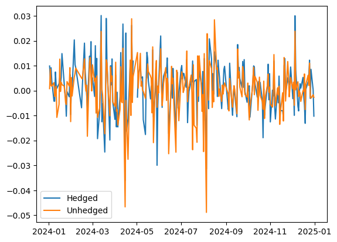

```python
plt.plot(hedged_portfolio)

plt.plot(R_portfolio_time_series)

plt.legend(['Hedged', 'Unhedged']);
```

Chúng ta sẽ kiểm tra tính chuẩn, tính đồng nhất phương sai và tự tương quan trong mô hình này. Để biết thêm thông tin về các bài kiểm tra bên dưới, hãy tham khảo bài giảng Vi phạm các mô hình hồi quy.

Để kiểm tra tính chuẩn, chúng ta sẽ thực hiện bài kiểm tra Jarque-Bera, bài kiểm tra này xem liệu độ lệch và độ nhọn của dữ liệu của chúng ta có phù hợp với phân phối chuẩn hay không. Theo tiêu chuẩn, chúng ta sẽ bác bỏ giả thuyết null rằng dữ liệu của chúng ta phân phối chuẩn nếu giá trị p-value của chúng ta dưới mức độ tin cậy 5%.

Để kiểm tra tính không đồng nhất phương sai, chúng ta sẽ thực hiện bài kiểm tra Breush-Pagan, bài kiểm tra này xem liệu phương sai của các sai số trong hồi quy tuyến tính có liên quan đến các giá trị của các biến độc lập hay không. Trong trường hợp này, giả thuyết nyll của chúng ta là dữ liệu là đồng nhất phương sai.

Tự tương quan được kiểm tra bằng cách sử dụng thống kê Durbin-Watson, thống kê này xem xét mối quan hệ trễ giữa các sai số trong một hồi quy. Điều này sẽ cho bạn một số giữa 0 và 4, với 2 có nghĩa là không có tự tương quan.

```python
# testing for normality: jarque-bera
_, pvalue_JB, _, _ = stats.stattools.jarque_bera(portfolio_exposure.resid)
print("Jarque-Bera p-value:", pvalue_JB)

# testing for homoskedasticity: breush pagan
_, pvalue_BP, _, _ = stats.diagnostic.het_breuschpagan(portfolio_exposure.resid, \
                                            pd.concat([x for i in random_assets]))
print("Breush Pagan p-value:", pvalue_BP)

# testing for autocorrelation
dw = stats.stattools.durbin_watson(portfolio_exposure.resid)
print("Durbin Watson statistic:", dw)
```

```
Jarque-Bera p-value: 0.0
Breush Pagan p-value: 1.9355589845920548e-08
Durbin Watson statistic: 2.024456215763012
```

Dựa trên giá trị p của kiểm định Jarque-Bera, chúng ta sẽ bác bỏ giả thuyết không rằng dữ liệu có phân phối chuẩn. Điều này có nghĩa là có bằng chứng mạnh mẽ cho thấy dữ liệu của chúng ta tuân theo một phân phối khác.

Kiểm định về tính đồng nhất phương sai (homoskedasticity) cho thấy dữ liệu là không đồng nhất phương sai (heteroskedastic). Tuy nhiên, chúng ta cần cẩn thận với kiểm định này vì chúng ta đã thấy rằng dữ liệu của chúng ta có thể không phân phối chuẩn.

Cuối cùng, thống kê Durbin-Watson có thể được đánh giá bằng cách xem các giá trị tới hạn của thống kê. Với giá trị kiểm định xấp xỉ 2, có nghĩa là dữ liệu của chúng ta không có tự tương quan.

## Phương pháp Hai: Chuẩn hóa Giá trị Yếu tố

Một phương pháp khác là chuẩn hóa giá trị yếu tố cho mỗi ngày và xem chúng dự đoán lợi nhuận của ngày hôm đó như thế nào. Điều này còn được gọi là phân tích yếu tố theo mặt cắt ngang (cross-sectional). Chúng ta thực hiện điều này bằng cách tính giá trị yếu tố chuẩn hóa $b_{a,j}$ cho mỗi tài sản $a$ theo cách sau.

$$b_{a,j} = \frac{F_{a,j} - \mu_{F_j}}{\sigma_{F_j}}$$

$F_{a,j}$ là giá trị của yếu tố $j$ cho tài sản $a$ trong thời gian này, $\mu_{F_j}$ là giá trị trung bình của yếu tố trên tất cả các tài sản, và $\sigma_{F_j}$ là độ lệch chuẩn của các giá trị yếu tố trên tất cả các tài sản. Lưu ý rằng chúng ta chỉ đang tính một điểm z để làm cho các giá trị yếu tố cụ thể của tài sản có thể so sánh được giữa các yếu tố khác nhau.

Các ngoại lệ cho công thức này là các biến nhị phân, được đặt thành 1 cho đúng và 0 cho sai. Một ví dụ là thành viên ngành: hệ số cho biết liệu tài sản có thuộc về ngành đó hay không.

Sau khi chúng ta tính toán tất cả các điểm số chuẩn hóa trong thời gian $t$, chúng ta có thể ước lượng lợi nhuận của yếu tố $j$ là $F_{j,t}$, sử dụng hồi quy theo mặt cắt ngang (tức là tại mỗi bước thời gian, chúng ta thực hiện một hồi quy sử dụng các phương trình cho tất cả các tài sản). Cụ thể, khi chúng ta có lợi nhuận cho mỗi tài sản $R_{a,t}$, và các hệ số yếu tố chuẩn hóa $b_{a,j}$, chúng ta xây dựng mô hình sau và ước lượng các $F_j$ và $a_t$

$$R_{a,t} = a_t + b_{a,F_1}F_1 + b_{a, F_2}F_2 + \dots + b_{a, F_K}F_K$$

Bạn có thể nghĩ về điều này như việc cắt theo hướng khác từ phân tích đầu tiên, vì bây giờ lợi nhuận yếu tố là các ẩn số cần được giải, trong khi ban đầu các hệ số là các ẩn số. Một cách khác để nghĩ về nó là bạn đang xác định yếu tố này có khả năng dự đoán lợi nhuận vào ngày hôm đó như thế nào, và do đó bạn có thể đã tạo ra bao nhiêu lợi nhuận từ yếu tố đó.

Theo quy trình này, chúng ta sẽ có lợi nhuận theo mặt cắt ngang vào ngày 22 tháng 11 năm 2024, và tính toán các hệ số cho tất cả các tài sản:

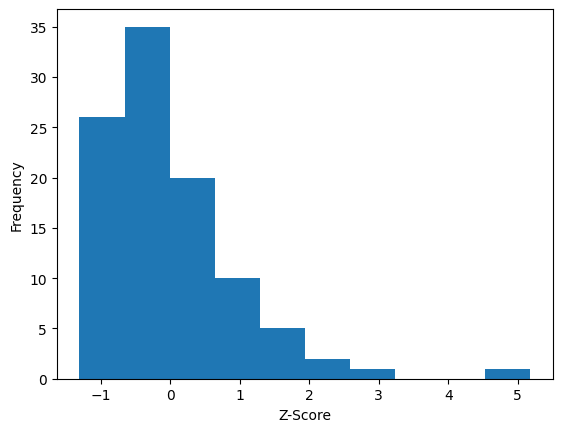

```python
date = '2024-11-22'

BTP = book_to_price.loc[date]
z_score = (BTP - BTP.mean()) / BTP.std()
z_score.dropna(inplace=True)

plt.hist(z_score)
plt.xlabel('Z-Score')
plt.ylabel('Frequency');
```

#### Vấn đề: Dữ liệu phân phối một cách kỳ lạ

Lưu ý rằng có những giá trị ngoại lệ lớn trong tập dữ liệu gây ra việc các điểm z-score mất rất nhiều thông tin. Về cơ bản, sự hiện diện của một số giá trị ngoại lệ rất lớn khiến phần còn lại của dữ liệu chiếm một khu vực tương đối nhỏ. Chúng ta có thể khắc phục vấn đề này bằng cách sử dụng một số kỹ thuật làm sạch dữ liệu, chẳng hạn như kỹ thuật winsorization.

#### Winsorization

Winsorization lấy $n\%$ giá trị cao nhất trong một tập dữ liệu và đặt tất cả chúng bằng giá trị ít cực đoan nhất trong $n\%$ đó. Ví dụ, nếu tập dữ liệu của bạn dao động từ 0-10, cộng với một vài giá trị ngoại lệ điên rồ, những giá trị ngoại lệ đó sẽ được đặt bằng 0 hoặc 10 tùy thuộc vào hướng của chúng. Dưới đây là một ví dụ.

```python
# Get some random data
random_data = np.random.normal(0, 1, 100)

# Put in some outliers
random_data[0] = 1000
random_data[1] = -1000

# Perform winsorization
print('Before winsorization', np.min(random_data), np.max(random_data))
scipy.stats.mstats.winsorize(random_data, inplace=True, limits=0.01)
print('After winsorization', np.min(random_data), np.max(random_data))
```

```
Before winsorization -1000.0 1000.0
After winsorization -3.157444502450402 1.9270065263985616
```

Chúng ta sẽ áp dụng cùng một kỹ thuật cho dữ liệu của mình và thu thập lợi nhuận của tất cả các tài sản trong tập vũ trụ của chúng ta. Sau đó, chúng ta sẽ thực hiện hồi quy tuyến tính để ước lượng $F_j$.

```python
BTP = scipy.stats.mstats.winsorize(book_to_price.loc[date], limits=0.01)
BTP_z = (BTP - np.mean(BTP)) / np.std(BTP)

MC = scipy.stats.mstats.winsorize(market_caps.loc[date], limits=0.01)
MC_z = (MC - np.mean(MC)) / np.std(MC)

Lag_Ret = scipy.stats.mstats.winsorize(momentum.loc[date], limits=0.01)
Lag_Ret_z = (Lag_Ret - np.mean(Lag_Ret)) / np.std(Lag_Ret)

df_day = pd.DataFrame({'R': returns.loc[date],
              'BTP_z': BTP_z,
              'MC_z': MC_z,
              'Lag_Ret_z': Lag_Ret_z,
              'Constant': 1}).dropna()

cross_sectional_results = \
    regression.linear_model.OLS(df_day['R'], df_day[['BTP_z', 'MC_z', 'Lag_Ret_z', 'Constant']]).fit()

cross_sectional_results.summary()
```

OLS Regression Results

| Dep. Variable: | R | R-squared: | 0.065 |
| --- | --- | --- | --- |
| Model: | OLS | Adj. R-squared: | 0.036 |
| Method: | Least Squares | F-statistic: | 2.224 |
| Date: | Sun, 27 Apr 2025 | Prob (F-statistic): | 0.0903 |
| Time: | 09:56:18 | Log-Likelihood: | 332.66 |
| No. Observations: | 100 | AIC: | -657.3 |
| Df Residuals: | 96 | BIC: | -646.9 |
| Df Model: | 3 |  |  |
| Covariance Type: | nonrobust |  |  |

|  | coef | std err | t | P>\|t\| | [0.025 | 0.975] |
| --- | --- | --- | --- | --- | --- | --- |
| BTP_z | -0.0003 | 0.001 | -0.362 | 0.718 | -0.002 | 0.002 |
| MC_z | 0.0015 | 0.001 | 1.608 | 0.111 | -0.000 | 0.003 |
| Lag_Ret_z | 0.0017 | 0.001 | 1.917 | 0.058 | -6.13e-05 | 0.004 |
| Constant | -0.0027 | 0.001 | -3.063 | 0.003 | -0.004 | -0.001 |

| Omnibus: | 19.378 | Durbin-Watson: | 2.151 |
| --- | --- | --- | --- |
| Prob(Omnibus): | 0.000 | Jarque-Bera (JB): | 58.255 |
| Skew: | -0.553 | Prob(JB): | 2.24e-13 |
| Kurtosis: | 6.572 | Cond. No. | 1.35 |

Notes:  
[1] Standard Errors assume that the covariance matrix of the errors is correctly specified.

Để mở rộng phân tích này, bạn chỉ cần lặp qua các ngày, thực hiện điều này mỗi ngày và nhận được một tỷ lệ lợi nhuận ước tính.

*Lưu ý: Tài liệu này mang tính chất chia sẻ kiến thức khoa học dữ liệu. Các mã chứng khoán xuất hiện trong tài liệu chỉ mang tính chất minh hoạ, không khuyến nghị đầu tư. Chúng tôi không chịu trách nhiệm trước mọi rủi ro nào do sử dụng tài liệu này.*